# Part I - (Prosper Loan Data)

## Introduction

In this document, we examine a dataset containing 113,937 loans with 81 variables for each loan: loan amount, borrower's interest rate (or rate), current loan status, borrower's income, etc.

## Preliminary Wrangling

```python
# import all packages and set plots to be embedded inline
import numpy as np
import pandas as pd
import matplotlib.pyplot as plt
import seaborn as sns

import warnings
warnings.filterwarnings('ignore')

%matplotlib inline

%config InlineBbackend.figure_format='retina'
```

> Load in your dataset and describe its properties through the questions below. Try and motivate your exploration goals through this section.

```python
# Import Prosper Loan Data csv file into jupyter notebook
df = pd.read_csv('prosperLoanData.csv')
```

```python
df.head()
```

|  | ListingKey | ListingNumber | ListingCreationDate | CreditGrade | Term | LoanStatus | ClosedDate | BorrowerAPR | BorrowerRate | LenderYield | ... | LP_ServiceFees | LP_CollectionFees | LP_GrossPrincipalLoss | LP_NetPrincipalLoss | LP_NonPrincipalRecoverypayments | PercentFunded | Recommendations | InvestmentFromFriendsCount | InvestmentFromFriendsAmount | Investors |
| --- | --- | --- | --- | --- | --- | --- | --- | --- | --- | --- | --- | --- | --- | --- | --- | --- | --- | --- | --- | --- | --- |
| 0 | 1021339766868145413AB3B | 193129 | 2007-08-26 19:09:29.263000000 | C | 36 | Completed | 2009-08-14 00:00:00 | 0.16516 | 0.1580 | 0.1380 | ... | -133.18 | 0.0 | 0.0 | 0.0 | 0.0 | 1.0 | 0 | 0 | 0.0 | 258 |
| 1 | 10273602499503308B223C1 | 1209647 | 2014-02-27 08:28:07.900000000 | NaN | 36 | Current | NaN | 0.12016 | 0.0920 | 0.0820 | ... | 0.00 | 0.0 | 0.0 | 0.0 | 0.0 | 1.0 | 0 | 0 | 0.0 | 1 |
| 2 | 0EE9337825851032864889A | 81716 | 2007-01-05 15:00:47.090000000 | HR | 36 | Completed | 2009-12-17 00:00:00 | 0.28269 | 0.2750 | 0.2400 | ... | -24.20 | 0.0 | 0.0 | 0.0 | 0.0 | 1.0 | 0 | 0 | 0.0 | 41 |
| 3 | 0EF5356002482715299901A | 658116 | 2012-10-22 11:02:35.010000000 | NaN | 36 | Current | NaN | 0.12528 | 0.0974 | 0.0874 | ... | -108.01 | 0.0 | 0.0 | 0.0 | 0.0 | 1.0 | 0 | 0 | 0.0 | 158 |
| 4 | 0F023589499656230C5E3E2 | 909464 | 2013-09-14 18:38:39.097000000 | NaN | 36 | Current | NaN | 0.24614 | 0.2085 | 0.1985 | ... | -60.27 | 0.0 | 0.0 | 0.0 | 0.0 | 1.0 | 0 | 0 | 0.0 | 20 |

5 rows × 81 columns

```python
df.info()
```

```
<class 'pandas.core.frame.DataFrame'>
RangeIndex: 113937 entries, 0 to 113936
Data columns (total 81 columns):
 #   Column                               Non-Null Count   Dtype
---  ------                               --------------   -----
 0   ListingKey                           113937 non-null  object
 1   ListingNumber                        113937 non-null  int64
 2   ListingCreationDate                  113937 non-null  object
 3   CreditGrade                          28953 non-null   object
 4   Term                                 113937 non-null  int64
 5   LoanStatus                           113937 non-null  object
 6   ClosedDate                           55089 non-null   object
 7   BorrowerAPR                          113912 non-null  float64
 8   BorrowerRate                         113937 non-null  float64
 9   LenderYield                          113937 non-null  float64
```

[output cut: 73 more lines]

```python
df.shape
```

```
(113937, 81)
```

```python
df.describe()
```

|  | ListingNumber | Term | BorrowerAPR | BorrowerRate | LenderYield | EstimatedEffectiveYield | EstimatedLoss | EstimatedReturn | ProsperRating (numeric) | ProsperScore | ... | LP_ServiceFees | LP_CollectionFees | LP_GrossPrincipalLoss | LP_NetPrincipalLoss | LP_NonPrincipalRecoverypayments | PercentFunded | Recommendations | InvestmentFromFriendsCount | InvestmentFromFriendsAmount | Investors |
| --- | --- | --- | --- | --- | --- | --- | --- | --- | --- | --- | --- | --- | --- | --- | --- | --- | --- | --- | --- | --- | --- |
| count | 1.139370e+05 | 113937.000000 | 113912.000000 | 113937.000000 | 113937.000000 | 84853.000000 | 84853.000000 | 84853.000000 | 84853.000000 | 84853.000000 | ... | 113937.000000 | 113937.000000 | 113937.000000 | 113937.000000 | 113937.000000 | 113937.000000 | 113937.000000 | 113937.000000 | 113937.000000 | 113937.000000 |
| mean | 6.278857e+05 | 40.830248 | 0.218828 | 0.192764 | 0.182701 | 0.168661 | 0.080306 | 0.096068 | 4.072243 | 5.950067 | ... | -54.725641 | -14.242698 | 700.446342 | 681.420499 | 25.142686 | 0.998584 | 0.048027 | 0.023460 | 16.550751 | 80.475228 |
| std | 3.280762e+05 | 10.436212 | 0.080364 | 0.074818 | 0.074516 | 0.068467 | 0.046764 | 0.030403 | 1.673227 | 2.376501 | ... | 60.675425 | 109.232758 | 2388.513831 | 2357.167068 | 275.657937 | 0.017919 | 0.332353 | 0.232412 | 294.545422 | 103.239020 |
| min | 4.000000e+00 | 12.000000 | 0.006530 | 0.000000 | -0.010000 | -0.182700 | 0.004900 | -0.182700 | 1.000000 | 1.000000 | ... | -664.870000 | -9274.750000 | -94.200000 | -954.550000 | 0.000000 | 0.700000 | 0.000000 | 0.000000 | 0.000000 | 1.000000 |
| 25% | 4.009190e+05 | 36.000000 | 0.156290 | 0.134000 | 0.124200 | 0.115670 | 0.042400 | 0.074080 | 3.000000 | 4.000000 | ... | -73.180000 | 0.000000 | 0.000000 | 0.000000 | 0.000000 | 1.000000 | 0.000000 | 0.000000 | 0.000000 | 2.000000 |
| 50% | 6.005540e+05 | 36.000000 | 0.209760 | 0.184000 | 0.173000 | 0.161500 | 0.072400 | 0.091700 | 4.000000 | 6.000000 | ... | -34.440000 | 0.000000 | 0.000000 | 0.000000 | 0.000000 | 1.000000 | 0.000000 | 0.000000 | 0.000000 | 44.000000 |
| 75% | 8.926340e+05 | 36.000000 | 0.283810 | 0.250000 | 0.240000 | 0.224300 | 0.112000 | 0.116600 | 5.000000 | 8.000000 | ... | -13.920000 | 0.000000 | 0.000000 | 0.000000 | 0.000000 | 1.000000 | 0.000000 | 0.000000 | 0.000000 | 115.000000 |
| max | 1.255725e+06 | 60.000000 | 0.512290 | 0.497500 | 0.492500 | 0.319900 | 0.366000 | 0.283700 | 7.000000 | 11.000000 | ... | 32.060000 | 0.000000 | 25000.000000 | 25000.000000 | 21117.900000 | 1.012500 | 39.000000 | 33.000000 | 25000.000000 | 1189.000000 |

8 rows × 61 columns

### What is the structure of your dataset?

The dataset contains 113,937 loans and 81 characteristics. The majority of variables are category and numerical in character.

There are two primary categories of features in the dataset:

Borrower details information about loan performance

### What is/are the main feature(s) of interest in your dataset?

Finding out which borrower characteristics can most accurately forecast a high rate of return is what I'm most interested in learning as an investor.

How closely did the estimated and actual loan performance match up?

### What features in the dataset do you think will help support your investigation into your feature(s) of interest?

Though there are many features to explore, I suspect the following borrower features will have the largest effect on the performance of the loan:

IncomeRange - The income range of the borrower at the time the listing was created. DebToIncomeRatio - The debt to income ratio of the borrower at the time the credit profile was pulled. This value is Null if the debt to income ratio is not available. This value is capped at 10.01 (any debt to income ratio larger than 1000% will be returned as 1001%). CreditGrade - The Credit rating that was assigned at the time the listing went live. Applicable for listings pre-2009 period and will only be populated for those listings. ProsperRating (Alpha) - The Prosper Rating assigned at the time the listing was created between AA - HR. Applicable for loans originated after July 2009.

## Univariate Exploration

#### Distribution of the Borrower rate

```python
# Most of the plots will have the same figure size, here I will set the default figure size
#    that will be used through out the exploration process, I will overide it when neccessary

figsize = (14,6)
```

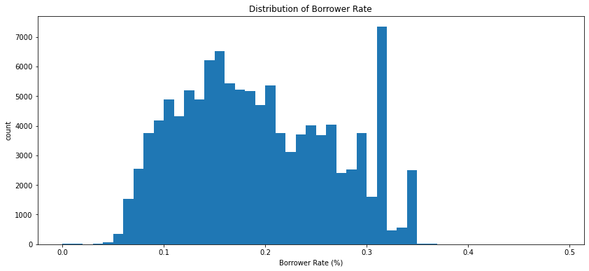

```python
# Plot the distribution of BorrowerRate
rate_bins = np.arange(df.BorrowerRate.min(), df.BorrowerRate.max(), 0.01)

# Set the size of the figure
plt.figure(figsize = figsize)

# Here I plot the histogram of the borrower rates
plt.hist(data=df, x='BorrowerRate', bins=rate_bins)

# Name the title and axes of the plot
plt.title('Distribution of Borrower Rate')
plt.xlabel('Borrower Rate (%)')
plt.ylabel('count')
plt.show()
```

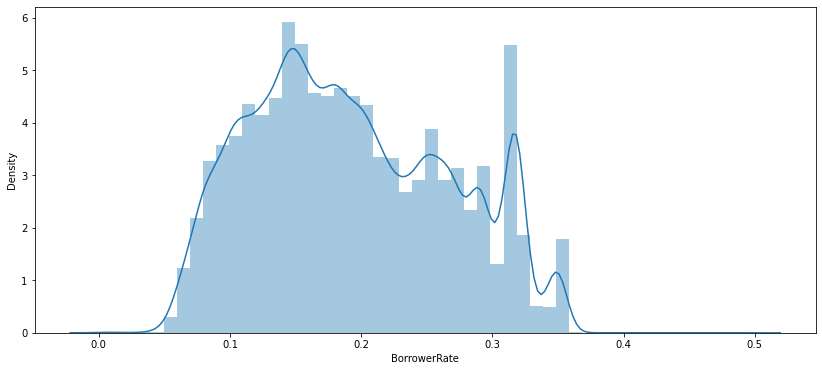

```python
# set dimensions of the plot
plt.figure(figsize = figsize)

# Plot the distribution
sns.distplot(df['BorrowerRate']);
```

#### Number of listings in each state

```python
# count of each state in the data
state_count = df.BorrowerState.value_counts()
state_count[0:5]
```

```
CA    14717
TX     6842
NY     6729
FL     6720
IL     5921
Name: BorrowerState, dtype: int64
```

```python
def Split_String(string):

    return ''.join([x if x.islower() else f' {x}' for x in string])
```

```python
def CountPlot_x(df, xVar, color = 0, order = None, figsize = figsize):

    '''
    This function takes:
       df - pandas data frame
       xVar - the variables to be shown on the x-axis
       color, order and fig size have default values for color, order and figure size

       >>> Returns a count plot with vertical bars

    '''


    plt.figure(figsize = figsize);
    sns.countplot(data = df, x = xVar, edgecolor = None, color = sns.color_palette()[color], order = order)
    xVar = Split_String(xVar).replace('_', '')
    plt.title(f'''Distribution of {xVar}'''.title(), fontsize = 12, weight = 'bold')
    plt.xlabel(xVar.title(), fontsize = 10, weight = 'bold')
    plt.ylabel('Count'.title(), fontsize = 10, weight = 'bold')
    plt.xticks(rotation = 90)
    return plt.show()
```

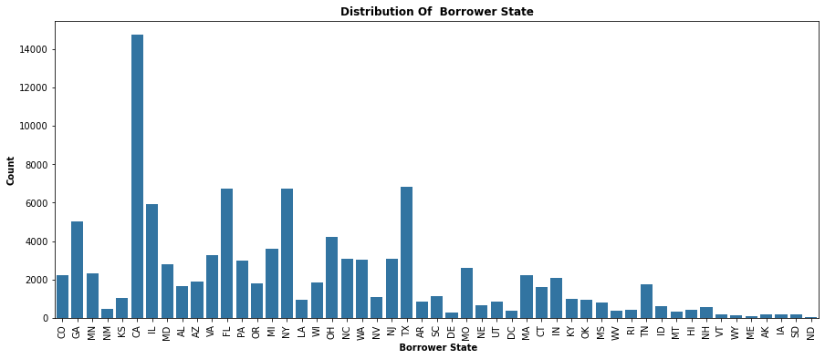

```python
# Use CountPlot function to plot Borrower state distribution

CountPlot_x(df, 'BorrowerState', figsize = (15,6))
```

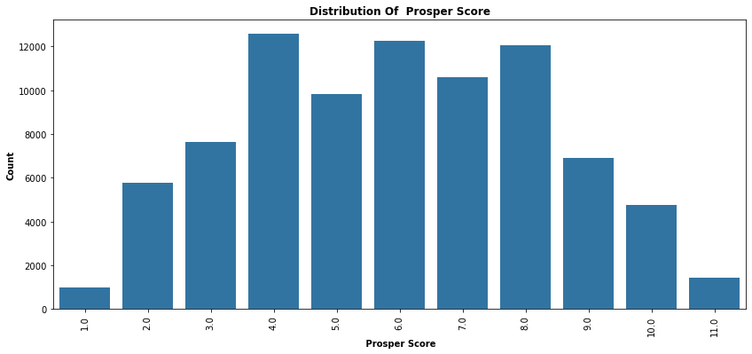

```python
# Use CountPlot function to plot Prosper score distribution

CountPlot_x(df, 'ProsperScore')
```

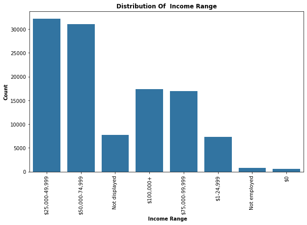

```python
# Use CountPlot function to plot the income range distribution

CountPlot_x(df, 'IncomeRange', figsize = (10,6))
```

Prosper grade

```python
df['ProsperRating (Alpha)'].describe(), df['ProsperRating (Alpha)'].value_counts()
```

```
(count     84853
 unique        7
 top           C
 freq      18345
 Name: ProsperRating (Alpha), dtype: object,
 C     18345
 B     15581
 A     14551
 D     14274
 E      9795
 HR     6935
 AA     5372
 Name: ProsperRating (Alpha), dtype: int64)
```

```python
df['CreditGrade'].describe(), df['CreditGrade'].value_counts()
```

```
(count     28953
 unique        8
 top           C
 freq       5649
 Name: CreditGrade, dtype: object,
 C     5649
 D     5153
 B     4389
 AA    3509
 HR    3508
 A     3315
 E     3289
 NC     141
 Name: CreditGrade, dtype: int64)
```

From the feature descriptions, it looks like Prosper transitioned to a "Prosper Rating" after 2009 to differentiate themselves from the industry standard "Credit Grade.

In the future we may want to look at estimated returns of the pre-2009 "Credit Grade" to see how it compares with the post-2009 "Prosper Rating" to validate if they truly are equivalent or if Prosper skewed their credit rating in some way.

```python
# replace NC with HR
df['CreditGrade'].replace(['NC', 'HR'], 'E', inplace = True)

# fill NA with empty strings
df['ProsperRating (Alpha)'].fillna("", inplace = True)
df['CreditGrade'].fillna("", inplace = True)

# combine credit ratings
df['ProsperRatingCombined'] = df['ProsperRating (Alpha)'] + df['CreditGrade']

# drop rows with no credit ratings
df = df.query(' ProsperRatingCombined != ""')

# check values
df['ProsperRatingCombined'].value_counts()
```

```
C     23994
B     19970
D     19427
A     17866
E     16733
AA     8881
HR     6935
Name: ProsperRatingCombined, dtype: int64
```

```python
# are the number of A and AA ratings the same before and after combining the columns?
(df['ProsperRatingCombined'] == 'A').sum() == (df.CreditGrade == 'A').sum() + (df['ProsperRating (Alpha)'] == 'A').sum() and \
(df['ProsperRatingCombined'] == 'AA').sum() == (df.CreditGrade == 'AA').sum() + (df['ProsperRating (Alpha)'] == 'AA').sum()
```

```
True
```

```python
# convert string to ordinal category type
ordinal_rating = ['AA', 'A', 'B', 'C', 'D', 'E']
ordered_var = pd.api.types.CategoricalDtype(ordered = True, categories = ordinal_rating)
df['ProsperRatingCombined'] = df['ProsperRatingCombined'].astype(ordered_var)
```

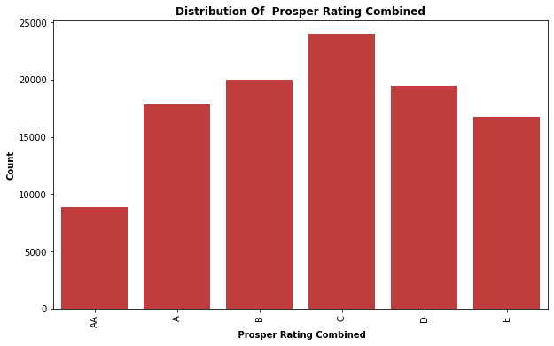

```python
# Plot the Prosper Rating combined
CountPlot_x(df, 'ProsperRatingCombined', color = 3, figsize = (10, 6))
```

#### Income Range

Let's continue our exploration by looking at a couple of the underwriting features for borrowers to be assigned these Credit Ratings. We'll start with taking a look at Income Ranges.

```python
df.IncomeRange.value_counts()
```

```
$25,000-49,999    32152
$50,000-74,999    31005
$100,000+         17321
$75,000-99,999    16899
Not displayed      7741
$1-24,999          7261
Not employed        806
$0                  621
Name: IncomeRange, dtype: int64
```

```python
# Replace Unemployed and Not Displayed with $0 in the dataframe

df['IncomeRange'].replace(['Not employed', 'Not displayed'], '$0', inplace = True)
```

```python
# create ordinal categories for income
ordinal_rating = ['$100,000+', '$75,000-99,999', '$50,000-74,999', '$25,000-49,999', '$1-24,999', '$0']
ordered_var = pd.api.types.CategoricalDtype(ordered = True, categories = ordinal_rating)
df['IncomeRange'] = df['IncomeRange'].astype(ordered_var)
```

```python
def CountPlot_y(df, yVar, palette = 0,order = None, figsize= (8,5)):
    '''
    *Args:
    df - dataframe
    yVar - y-variables
    palette - default = 0
    order - default = none
    figsize = default = (8,5)
    >>> Returns count plot with vertical bars
    '''
    plt.figure(figsize = figsize);
    sns.countplot(data = df, y = yVar, edgecolor = None, palette=palette,  order = order)
    yVar = Split_String(yVar).replace('_', '')
    plt.title(f'''Distribution of {yVar}'''.title(), fontsize = 12, weight = 'bold')
    plt.xlabel('Count'.title(), fontsize = 10, weight = 'bold')
    plt.ylabel(yVar.title(), fontsize = 10, weight = 'bold')

    return plt.show()
```

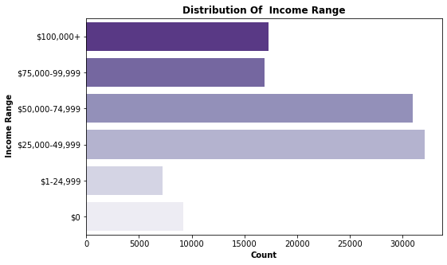

```python
CountPlot_y(df, 'IncomeRange', palette = 'Purples_r')
```

### Debt to Income Ratio

Of course your income is only part of the picture, let's see what the borrower's Debt to Income Ratio is like. I imagine a creditor wants to make sure you're not overleveraged in the event you have a loss of income and are unable to repay all of your debts.

```python
df.DebtToIncomeRatio.describe()
```

```
count    105263.000000
mean          0.275976
std           0.551811
min           0.000000
25%           0.140000
50%           0.220000
75%           0.320000
max          10.010000
Name: DebtToIncomeRatio, dtype: float64
```

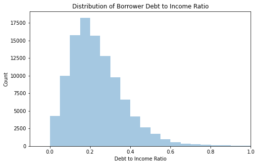

```python
# distribution plot of Borrower debt to income ratio
plt.figure(figsize = [8,5])
sns.distplot(df.DebtToIncomeRatio, kde = False, bins = 200)
plt.xlim(-.1, 1)
plt.xlabel('Debt to Income Ratio')
plt.ylabel('Count')
plt.title('Distribution of Borrower Debt to Income Ratio');
```

## Bivariate Exploration

### What are the main factors that contribute towards the loan's interest Rate?

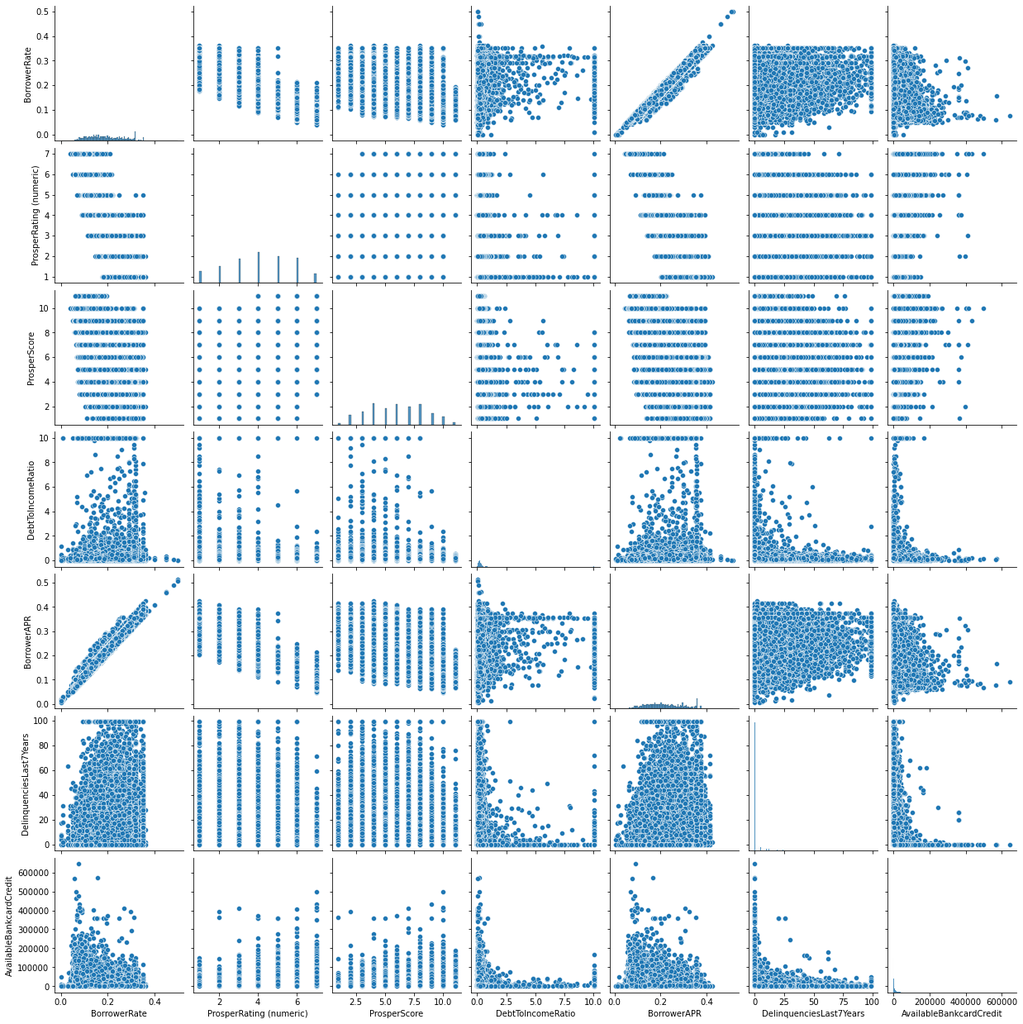

```python
sns.pairplot(df[['BorrowerRate', 'ProsperRating (numeric)', 'ProsperScore', 'DebtToIncomeRatio','BorrowerAPR',
                'DelinquenciesLast7Years','AvailableBankcardCredit']]);
```

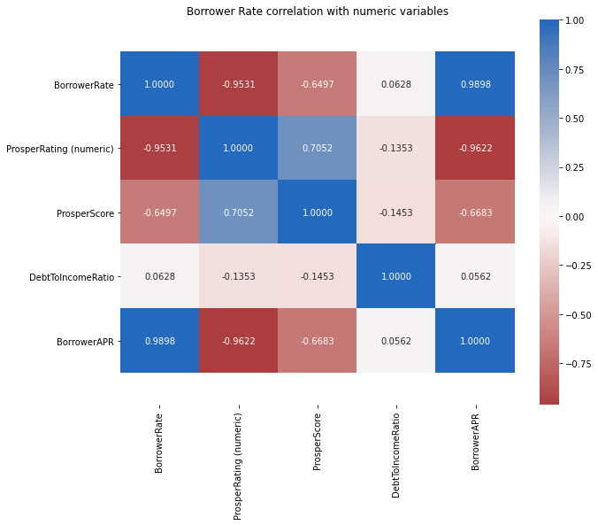

```python
correlation_df = df[['BorrowerRate', 'ProsperRating (numeric)', 'ProsperScore', 'DebtToIncomeRatio','BorrowerAPR']]

# correlation plot
plt.figure(figsize = [10, 8])
sns.heatmap(correlation_df.corr(), annot = True, fmt = '.4f',
           cmap = 'vlag_r', center = 0)
plt.title('Borrower Rate correlation with numeric variables')

#I could not see the complete matrix over here, hence got help via github
# Link- https://github.com/mwaskom/seaborn/issues/1773#issuecomment-546466986
bottom, top = plt.ylim()
bottom += 0.5
top -= 0.5
plt.ylim(bottom, top)
plt.yticks(rotation=0);
plt.show()
```

ProsperRating (number) is highly correlated with BorrowerRate and ProsperScore And DebtToIncomeRatio is not correlated at all.

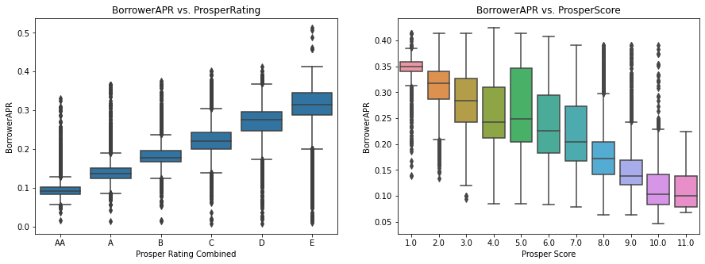

```python
plt.figure(figsize = [15, 5])

plt.subplot(1, 2, 1)
base_color=sns.color_palette()[0]
sns.boxplot(data = df, x = 'ProsperRatingCombined', y = 'BorrowerAPR',color=base_color)
plt.title('BorrowerAPR vs. ProsperRating')
plt.xlabel('Prosper Rating Combined')
plt.ylabel('BorrowerAPR')

plt.subplot(1, 2, 2)
sns.boxplot(data = df, x = 'ProsperScore', y = 'BorrowerAPR',)
plt.title('BorrowerAPR vs. ProsperScore')
plt.xlabel('Prosper Score')
plt.ylabel('BorrowerAPR');
```

#### Qualitative vs. Qualitiative

Let's continue to explore this thread by also plotting the credit score along with the income range.

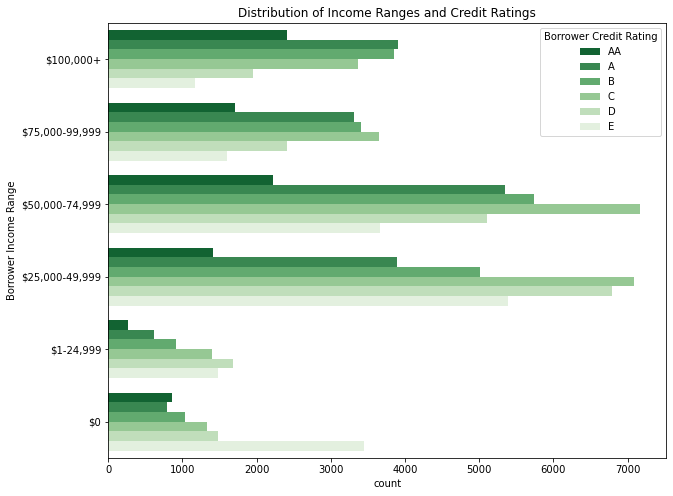

```python
# clustered bar chart
plt.figure(figsize = [10,8])

ax = sns.countplot(data = df, y = 'IncomeRange', hue = 'ProsperRatingCombined',
                   palette = 'Greens_r')

ax.legend(title = 'Borrower Credit Rating')
plt.title('Distribution of Income Ranges and Credit Ratings')
plt.ylabel('Borrower Income Range');
```

From this clustered bar chart, we can see the trend of higher incomes correlate to a higher credit rating qualifying the borrower for the best (lowest) interest rates.

Having an income of $75k+ doesn't automatically guarantee the best credit ratings. I'm curious to see in the multivariate analysis what other factors play a big role in determining one's credit rating.

Conversely, it also appears that in the $0 income range, there are a high amount of "AA" loans relative to the \$1-25k income range. I hypothesize you must have other significant assets or a great history with the platform to receive the highest credit rating without any income!

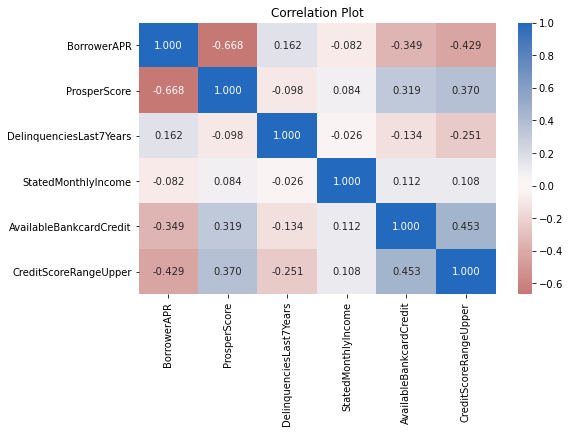

```python
# correlation plot

num_vars = ['BorrowerAPR', 'ProsperScore', 'DelinquenciesLast7Years',
            'StatedMonthlyIncome', 'AvailableBankcardCredit', 'CreditScoreRangeUpper']

plt.figure(figsize = [8, 5])
sns.heatmap(df[num_vars].corr(), annot = True, fmt = '.3f',
           cmap = 'vlag_r', center = 0)
plt.title('Correlation Plot')
plt.show()
```

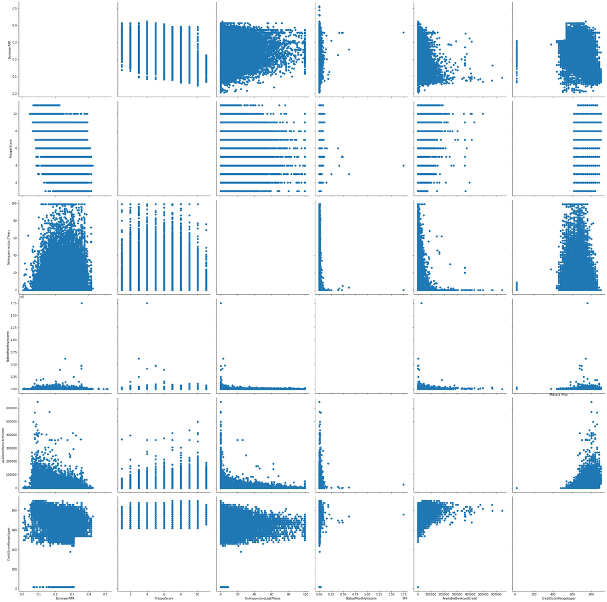

```python
# plot matrix: only 300 random loans are used to see the pattern more clearer


num_vars = ['BorrowerAPR', 'ProsperScore', 'DelinquenciesLast7Years',
            'StatedMonthlyIncome', 'AvailableBankcardCredit', 'CreditScoreRangeUpper']

g = sns.PairGrid(data = df, vars = num_vars, size = 5)
g.map_offdiag(plt.scatter)
plt.title('Matrix Plot');
```

## Multivariate Exploration

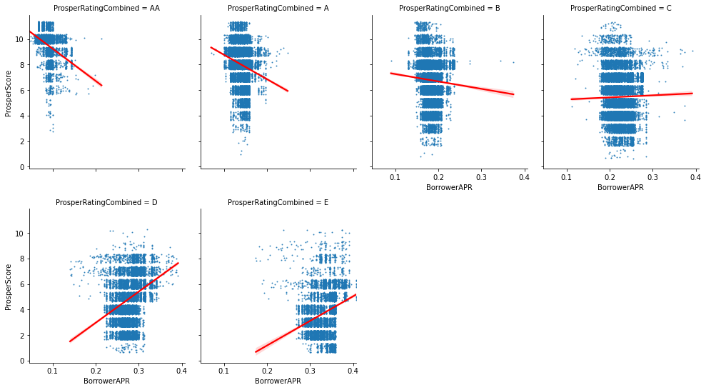

```python
grid = sns.FacetGrid(data = df, col = 'ProsperRatingCombined', col_wrap = 4, size = 3)
grid.map(sns.regplot, 'BorrowerAPR', 'ProsperScore', y_jitter = 0.35,
         scatter_kws = {'s':1},  line_kws ={'color':'red'})
grid.set_xlabels('BorrowerAPR')
grid.set_ylabels('ProsperScore')
grid.fig.set_size_inches(14,8)
plt.show();
```

## Conclusions

### Some of the relationships observed in this part of the investigation

Correlation plots and matrix plots from the previous plots can also be counted as part of the multivariate search. For greater efficiency, these two plots can be created early in the investigation to preview all variables and their interactions. Additionally, FacetGrid shows how each rating group differs with respect to his BorrowerAPR and ProsperScore.